# 2025 Spring BIO 2100 Final Creation and Answers

## Instructions! Read this first.

The exam is open note, open course website, open class-related code repositories (mine and those you produced in class). However, you may not get external help ( from other students, directed internet searches, etc.). Please update the statement below to acknowledge these instructions (and that you can use git).

The exam should be committed and pushed to github by Friday, 5/16/2025, at 12:30 PM. You can also commit and push along the way, but please mark your final commit (when you are finished) with the comment **Finished - ready to grade!.**

For all questions, the statement is based on what you might hear from a colleague or client if you were a statistical consultant (e.g., “How do I analyze this?”). This is like when you get a call to review a paper. Please answer questions succinctly but with necessary details on all required steps/concerns you might need to consider.

While the exam is based on a realistic scenario (with citations), some data and scenarios are fictional and contrived for the exam (i.e., don’t quote all this as fact!).

Good luck!

## Background

Earlier this year a company announced they had “resurrected” dire wolves by gene editing gray wolf embryos@newsat2025.

[figure not shown]

Screenshot from Science News announcing dire wolf resurrection (4/11/2025)

Colossal Biosciences, the company that led the dire wolf project, has asked you, a summer intern, to help analyze some of their data. It turns out they actually have produced a lot more wolves than they shared with the public (this is the made up part of the exam!).

## 1

Dire wolves were larger than today’s gray wolves. The average male gray wolf weighs 31 kg. Data below on 26 adult dire wolves the company has produced is available using

```r
set.seed(29)
male_dire_weight <- data.frame(mass_kg = c(round(rnorm(26, 38, 4),2)))
write.csv(male_dire_weight, "male_dire_weight.csv", row.names = F)
rm(male_dire_weight)
```

```r
male_dire_weight <- read.csv("male_dire_weight.csv", stringsAsFactors = T)
```

Analyze the data. Make sure you include

- null hypothesis (1 point)
  - H<sub>0</sub>: the average weight of dire wolves is 31 kg
- alternative hypothesis (1 point)
  - H<sub>A</sub>: the average weight of dire wolves is not 31 kg
- explanation for test you will use (1.5 point)
  - I would use a one-sample t-test because its continuous data from a single population. I also don’t know the variance but believe the means are normally distributed.
- results from statistical test (1 point)

  ```r
  t.test(male_dire_weight$mass_kg, mu=31)
  ```

  ```
      One Sample t-test

  data:  male_dire_weight$mass_kg
  t = 8.9497, df = 25, p-value = 2.865e-09
  alternative hypothesis: true mean is not equal to 31
  95 percent confidence interval:
   36.96210 40.52636
  sample estimates:
  mean of x
   38.74423
  ```

  - clear explanation of how results relate to your stated hypotheses (1.5 point)
    - Given a t<sub>25</sub>=8.95 and corresponding p<.001, I reject the null hypothesis. It appears the dire wolves are larger than 31 kg.

```r
t.test(male_dire_weight$mass_kg, mu=31)
```

```
    One Sample t-test

data:  male_dire_weight$mass_kg
t = 8.9497, df = 25, p-value = 2.865e-09
alternative hypothesis: true mean is not equal to 31
95 percent confidence interval:
 36.96210 40.52636
sample estimates:
mean of x
 38.74423
```

## 2

A few years later, the company has produced three “lines” of dire wolves using different gene editing techniques. Is there any evidence the three lines differ in mean weight? Data is available using

```r
set.seed(29)
male_dire_weight_groups <- data.frame(line = c(rep("a", 26), rep("b", 24), rep("c", 27)), mass_kg = c(round(rnorm(77, 38, 4),2)))
write.csv(male_dire_weight_groups, "male_dire_weight_groups.csv", row.names = F)
rm(male_dire_weight_groups)
```

```r
male_dire_weight_groups <- read.csv("male_dire_weight_groups.csv", stringsAsFactors = T)
```

Analyze the data. Make sure you include

- null hypothesis (1 point)
  - H<sub>0</sub>: there is no difference in mean/average weight among the three lines
  - H<sub>0</sub>: the average weight of the three lines are equal to each other/are the same
- alternative hypothesis (1 point)
  - H<sub>A</sub>: there is a difference in mean/average weight among the three lines
  - H<sub>A</sub>: the average weight of the three lines are not equal to each other/are the same
- explanation for test you will use (1.5 point)
  - I will use an anova/lm to consider how means differ among groups.
- results from statistical test (1 point)

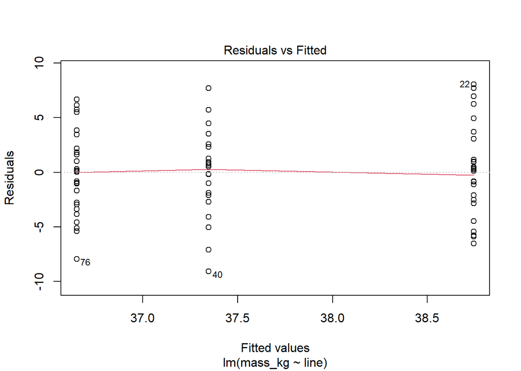

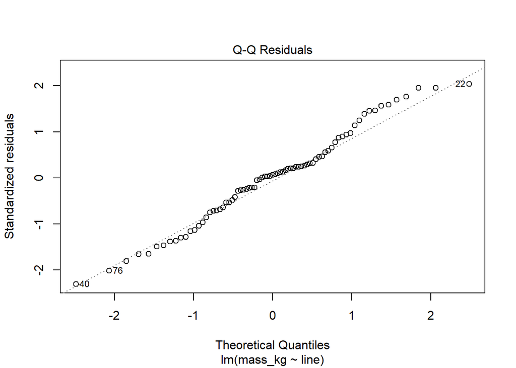

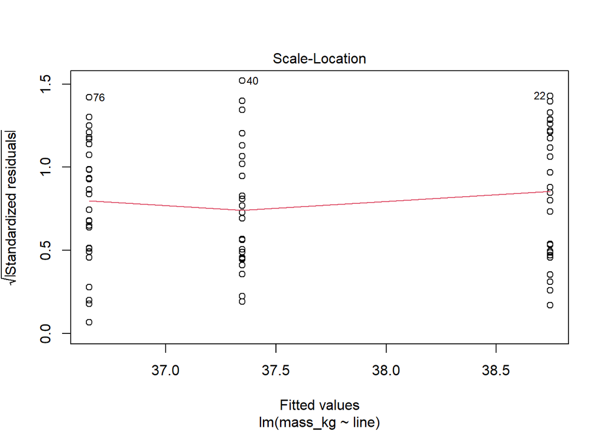

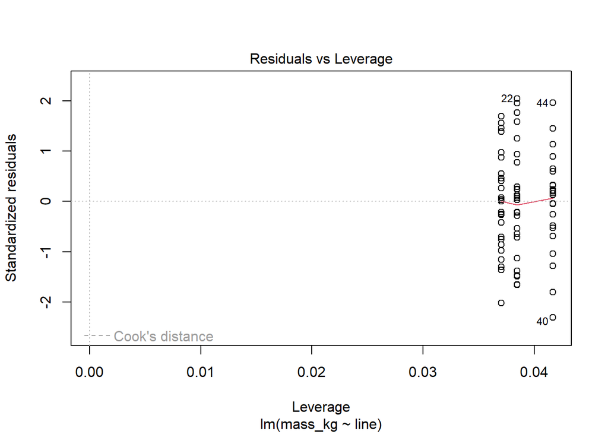

  ```r
  group_lm <- lm(mass_kg~line, male_dire_weight_groups)
  plot(group_lm)
  ```

  ```r
  library(car)
  Anova(group_lm, type="III")
  ```

  ```
  Anova Table (Type III tests)

  Response: mass_kg
              Sum Sq Df   F value Pr(>F)
  (Intercept)  39029  1 2413.0322 <2e-16 ***
  line            60  2    1.8486 0.1646
  Residuals     1197 74
  ---
  Signif. codes:  0 '***' 0.001 '**' 0.01 '*' 0.05 '.' 0.1 ' ' 1
  ```

- clear explanation of how results relate to your stated hypotheses (1.5 point)
  - Assumptions for the test were checked and met. Given a resulting F<sub>2,74</sub>=1.85 and corresponding p = .17, I fail to reject the null hypothesis. Line does not appear to impact average wolf weight.

## 3

Dire wolves are also supposed to have smaller snouts relative to their body length than regular wolves. The company provided data from 25 of their dire wolves and 26 of the gray wolves that were used to source embryos. Is there evidence the dire wolves are different than gray wolves? Data is available using

```r
set.seed(19)
snout_body_data <- data.frame(wolf = c(rep("gray", 26), rep("dire", 25)), body_length_cm = c(rep(rnorm(51, 60*2.54, 6))))
snout_body_data$snout_length_cm <- NA
snout_body_data[snout_body_data$wolf=="gray", "snout_length_cm"] <- snout_body_data[snout_body_data$wolf=="gray", "body_length_cm"]*(.2+runif(26,0,1)*.01)
snout_body_data[snout_body_data$wolf=="dire", "snout_length_cm"] <- snout_body_data[snout_body_data$wolf=="dire", "body_length_cm"]*(.1+runif(25,0,1)*.01)
write.csv(snout_body_data, "snout_body_data.csv", row.names = F)
rm(snout_body_data)
```

```r
snout_body_data <- read.csv("snout_body_data.csv", stringsAsFactors = T)
```

Make sure you include

- null hypothesis (1 point)
  - H<sub>0</sub>: snout length is the same among wolf types
  - H<sub>0</sub>: snout length is not related to body length
  - H<sub>0</sub>: the relationship between snout length and body length does not differ among wolf types
- alternative hypothesis (1 point)
  - H<sub>A</sub>: snout length is not the same among wolf types
  - H<sub>A</sub>:snout length is related to body length
  - H<sub>A</sub>: the relationship between snout length and body length does differ among wolf types
- explanation for test you will use (1.5 point)
  - I will use an ANCOVA because I’m considering a numerical response variable and how it is explained by both a numerical explanatory variable and a categorical explanatory variable and potential interactions among them.
- results from statistical test (1 point)

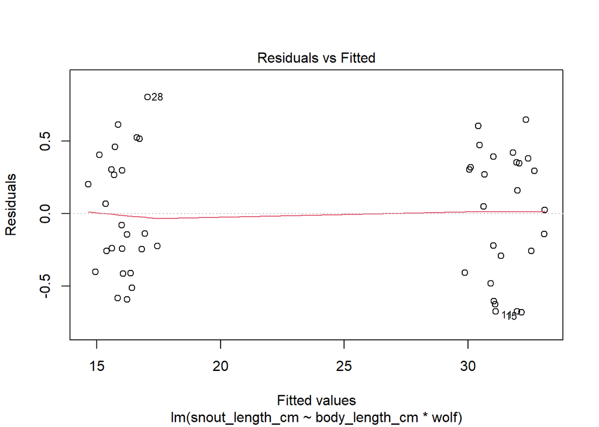

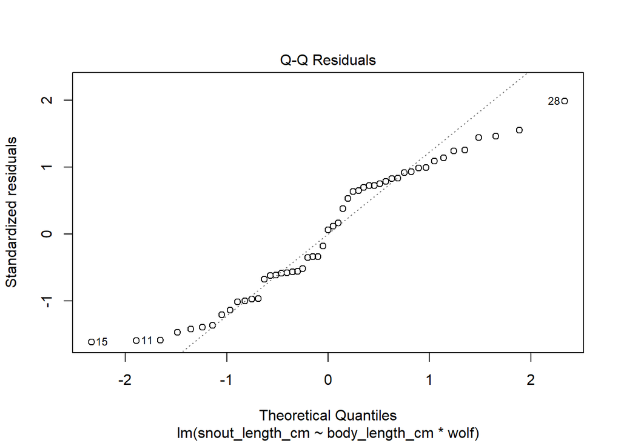

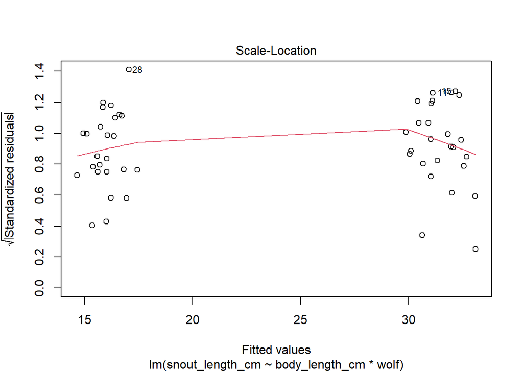

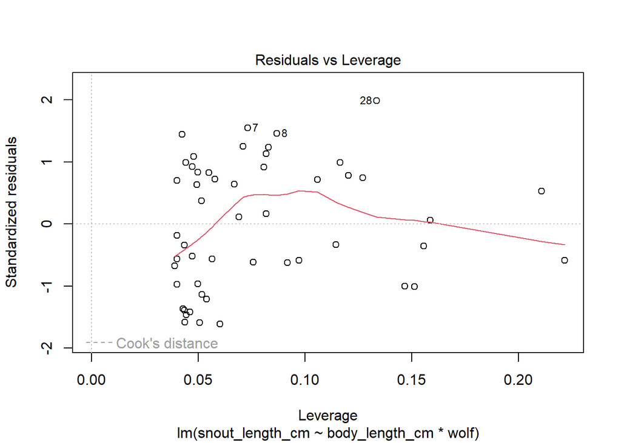

  ```r
  snout_body_data_lm <- lm(snout_length_cm~body_length_cm*wolf, snout_body_data)
  plot(snout_body_data_lm)
  ```

  Asssumptions appear to be met, so I continued with analysis.

  ```r
  Anova(snout_body_data_lm, type="III")
  ```

  ```
  Anova Table (Type III tests)

  Response: snout_length_cm
                       Sum Sq Df F value    Pr(>F)
  (Intercept)          0.3386  1  1.7924    0.1871
  body_length_cm      11.0475  1 58.4767 8.608e-10 ***
  wolf                 0.0914  1  0.4837    0.4902
  body_length_cm:wolf  5.2139  1 27.5985 3.553e-06 ***
  Residuals            8.8793 47
  ---
  Signif. codes:  0 '***' 0.001 '**' 0.01 '*' 0.05 '.' 0.1 ' ' 1
  ```

  There is a significant interaction between body and snout length based of wolf type (F<sub>1,47</sub>=27.6, p <.01), so I considered the relationship for each wolf type.

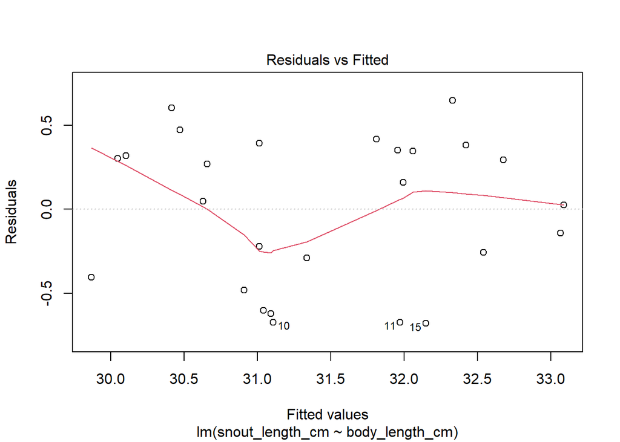

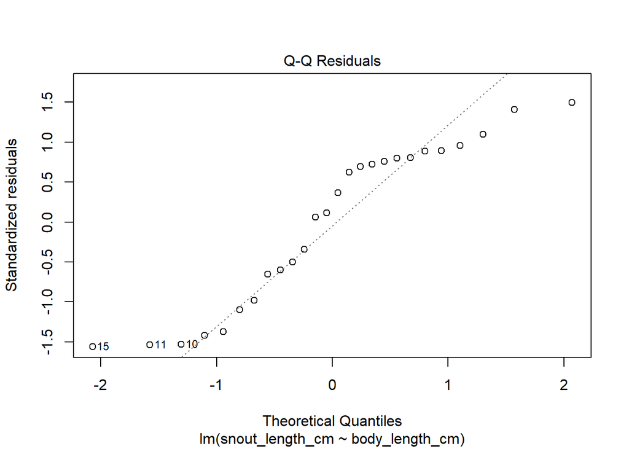

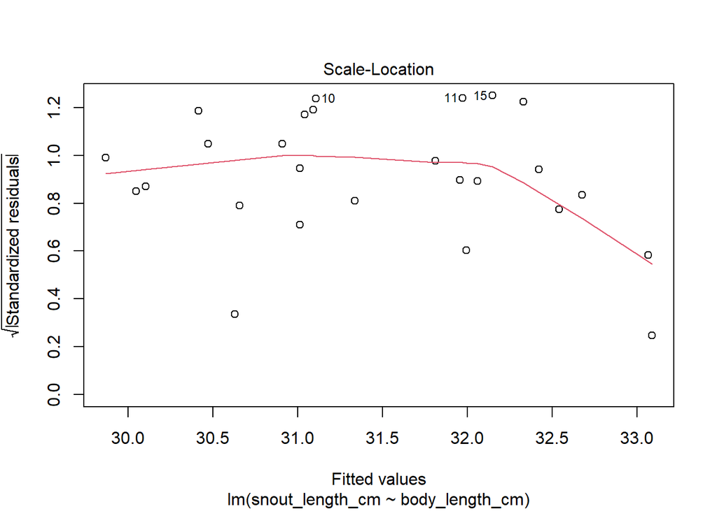

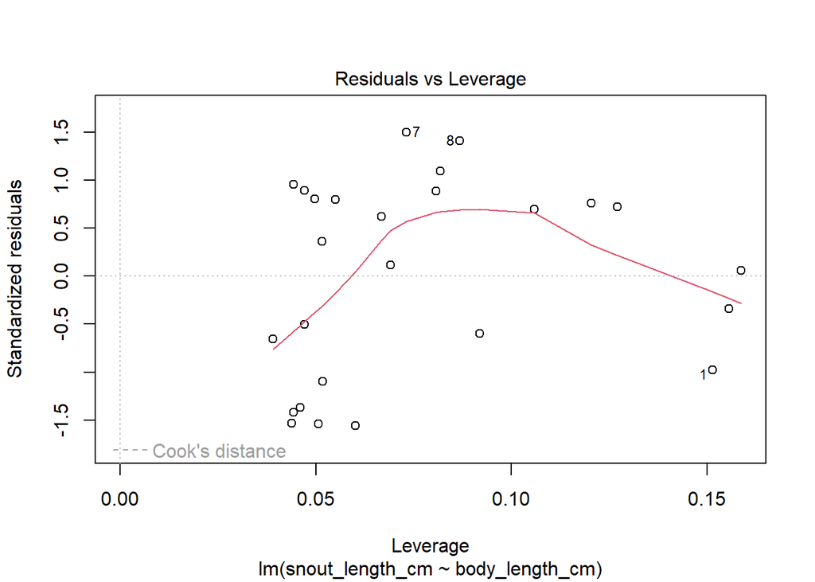

  ```r
  snout_body_data_lm_gray <- lm(snout_length_cm~body_length_cm, snout_body_data[snout_body_data$wolf == "gray",])
  plot(snout_body_data_lm_gray)
  ```

  ```r
  Anova(snout_body_data_lm_gray, type="III")
  ```

  ```
  Anova Table (Type III tests)

  Response: snout_length_cm
                 Sum Sq Df  F value    Pr(>F)
  (Intercept)     0.000  1   0.0001    0.9936
  body_length_cm 22.255  1 109.9713 1.927e-10 ***
  Residuals       4.857 24
  ---
  Signif. codes:  0 '***' 0.001 '**' 0.01 '*' 0.05 '.' 0.1 ' ' 1
  ```

  ```r
  summary(snout_body_data_lm_gray)
  ```

  ```
  Call:
  lm(formula = snout_length_cm ~ body_length_cm, data = snout_body_data[snout_body_data$wolf ==
      "gray", ])

  Residuals:
      Min      1Q  Median      3Q     Max
  -0.6809 -0.3764  0.1044  0.3521  0.6488

  Coefficients:
                 Estimate Std. Error t value Pr(>|t|)
  (Intercept)     0.02435    2.99836   0.008    0.994
  body_length_cm  0.20545    0.01959  10.487 1.93e-10 ***
  ---
  Signif. codes:  0 '***' 0.001 '**' 0.01 '*' 0.05 '.' 0.1 ' ' 1

  Residual standard error: 0.4499 on 24 degrees of freedom
  Multiple R-squared:  0.8209,    Adjusted R-squared:  0.8134
  F-statistic:   110 on 1 and 24 DF,  p-value: 1.927e-10
  ```

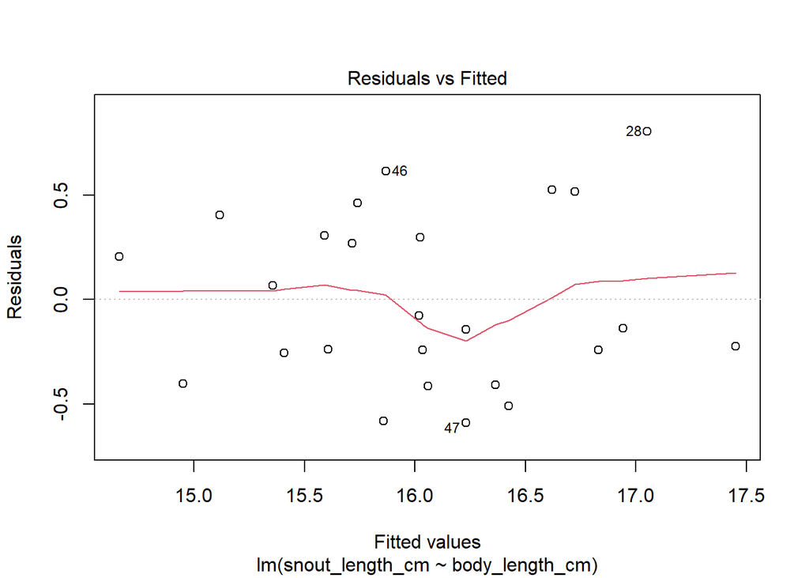

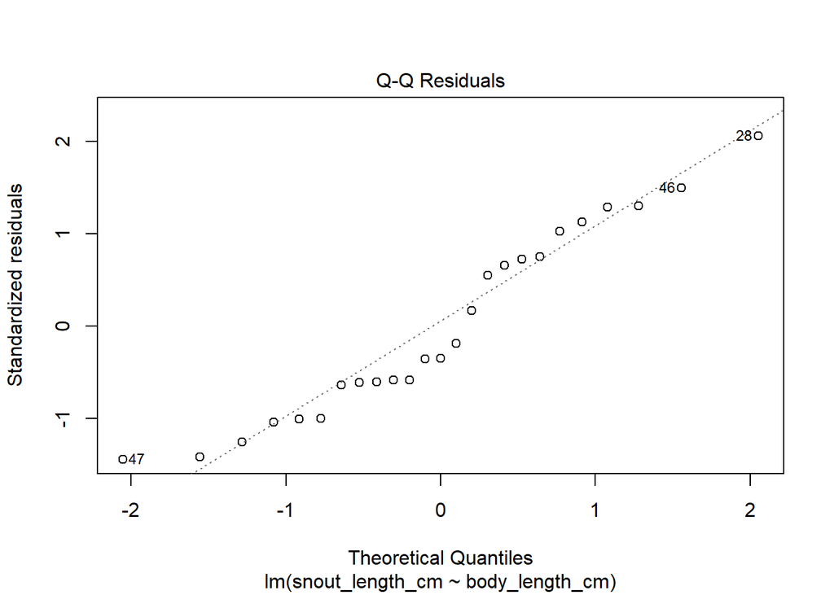

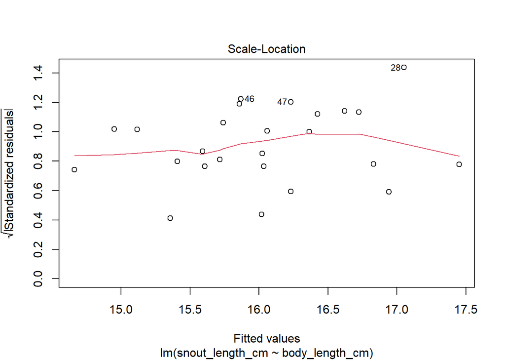

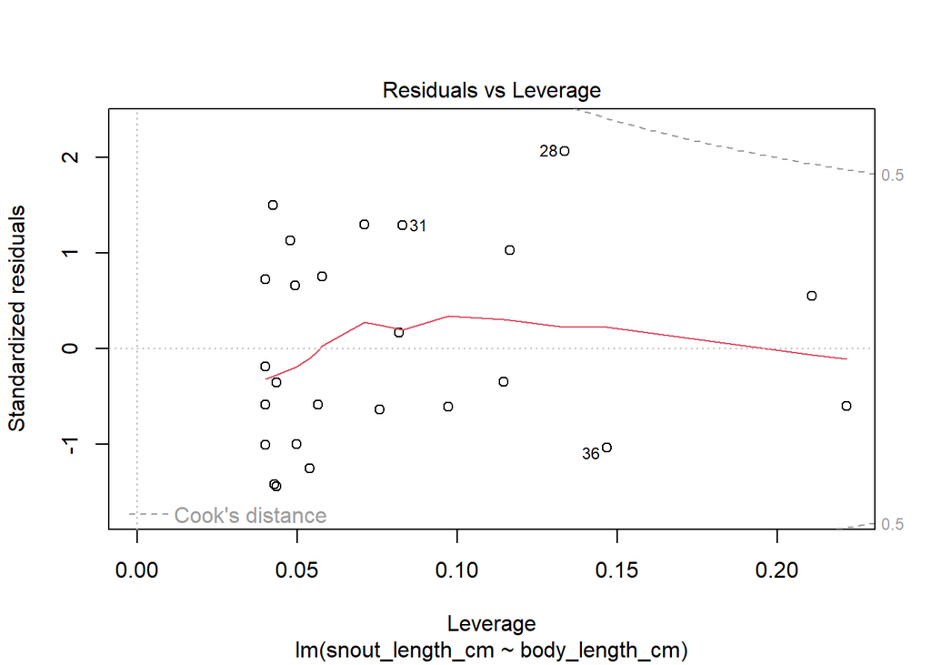

  ```r
  snout_body_data_lm_dire <- lm(snout_length_cm~body_length_cm, snout_body_data[snout_body_data$wolf == "dire",])
  plot(snout_body_data_lm_dire)
  ```

  ```r
  Anova(snout_body_data_lm_dire, type="III")
  ```

  ```
  Anova Table (Type III tests)

  Response: snout_length_cm
                  Sum Sq Df F value    Pr(>F)
  (Intercept)     0.3386  1  1.9362    0.1774
  body_length_cm 11.0475  1 63.1707 4.796e-08 ***
  Residuals       4.0223 23
  ---
  Signif. codes:  0 '***' 0.001 '**' 0.01 '*' 0.05 '.' 0.1 ' ' 1
  ```

  ```r
  summary(snout_body_data_lm_dire)
  ```

  ```
  Call:
  lm(formula = snout_length_cm ~ body_length_cm, data = snout_body_data[snout_body_data$wolf ==
      "dire", ])

  Residuals:
      Min      1Q  Median      3Q     Max
  -0.5915 -0.2571 -0.1373  0.3049  0.8041

  Coefficients:
                 Estimate Std. Error t value Pr(>|t|)
  (Intercept)     2.39150    1.71866   1.391    0.177
  body_length_cm  0.08879    0.01117   7.948  4.8e-08 ***
  ---
  Signif. codes:  0 '***' 0.001 '**' 0.01 '*' 0.05 '.' 0.1 ' ' 1

  Residual standard error: 0.4182 on 23 degrees of freedom
  Multiple R-squared:  0.7331,    Adjusted R-squared:  0.7215
  F-statistic: 63.17 on 1 and 23 DF,  p-value: 4.796e-08
  ```

- clear explanation of how results relate to your stated hypotheses (1.5 point)
  - Given the significant interaction, I considered the snout-body length relationship for each wolf type. Although the relationship is significant for both types, it appears that the snout length is shorter relative to body length for dire wolves compared to gray wolves (slopes of .08 vs .2, respectively; all p<.01).

## 4

Plot the data from question 3

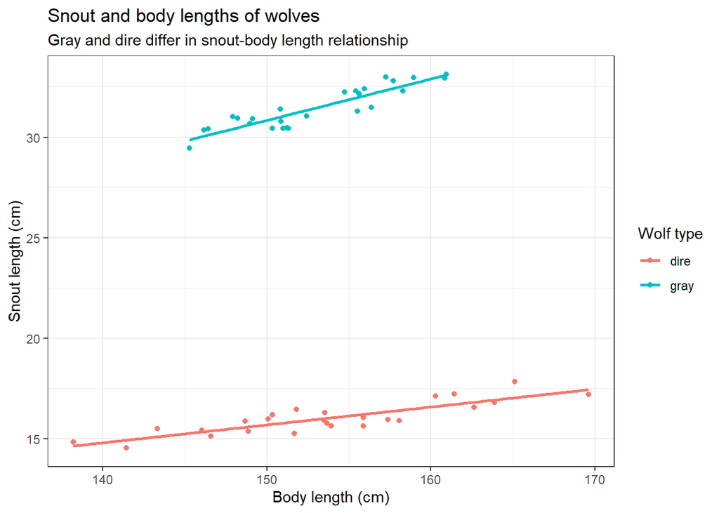

```r
library(ggplot2)
ggplot(snout_body_data, aes(x=body_length_cm, y=snout_length_cm, color=wolf))+
  geom_point()+
  geom_smooth(method='lm', se=F)+
  labs(title="Snout and body lengths of wolves",
       subtitle = "Gray and dire differ in snout-body length relationship",
       y="Snout length (cm)",
       x = "Body length (cm)",
       color= "Wolf type")+
  theme_bw()
```

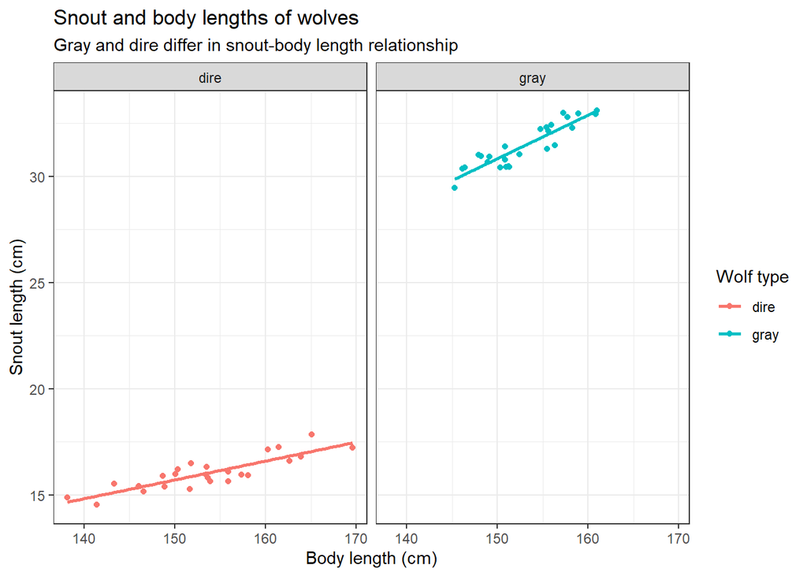

```r
ggplot(snout_body_data, aes(x=body_length_cm, y=snout_length_cm, color=wolf))+
  geom_point()+
  geom_smooth(method='lm', se=F)+
  labs(title="Snout and body lengths of wolves",
       subtitle = "Gray and dire differ in snout-body length relationship",
       y="Snout length (cm)",
       x = "Body length (cm)",
       color= "Wolf type")+
  theme_bw()+
  facet_wrap(~wolf)
```

## 5

The company also wants to know if the proportion of dire wolves born with white fur (a hallmark of dire wolves) is different than that of the gray wolves that provided the embryos (ignore any genetic issues here!). 18% of the parent gray wolves were white. For the litter in question, 18 out of 25 wolves were white. How would statistically analyze this?

How would you analyze the data. Make sure you include

- null hypothesis (1 point)
  - H<sub>0</sub>: proportion of white dire wolves is equal to 18%
- alternative hypothesis (1 point)
  - H<sub>A</sub>: proportion of white dire wolves is not equal to 18%
- explanation for test you will use (1.5 point)
  - We will analyze this data using a binomial test because we are comparing a proportion to a set value
- results from statistical test (1 point)

  ```r
  #could use prop.test instead
  binom.test(18, 25, .18)
  ```

  ```
      Exact binomial test

  data:  18 and 25
  number of successes = 18, number of trials = 25, p-value = 5.123e-09
  alternative hypothesis: true probability of success is not equal to 0.18
  95 percent confidence interval:
   0.5061232 0.8792833
  sample estimates:
  probability of success
                    0.72
  ```

- clear explanation of how results relate to your stated hypotheses (1.5 point)
  - Given a p-value <.01, I reject the null hypothesis; it appears dire wolves are more likely to be white.